# Inférence d’un réseau entre stations météorologigues

Inférence d’un réseau entre stations météorologigues Université de Bordeaux - M2 MAS MSS, CMI ISI, SI - UE : Statistique en grande dimension Année 2021-2022

**Nom : LAAMOUMRI**  
**Prénom : Yassine**

**Nom :LUWEH ADJIM NGARTI**  
**Prénom : Exaucé**

Dans ce projet, il est proposé d’analyser un jeu de données issues de mesures prises en différentes stations météorologiques durant l’année 2016 dans le nord-ouest de la France. Le but de projet est l’inférence d’un graphe de corrélation partielle entre certaines variables météorologiques à l’aide des outils d’estimation en grande dimension dans des modèles graphiques.

#### Données disponibles sur les stations de mesure

Sur l’année 2016, on observe des données d’apprentissage sur $p = 262$ stations météorologiques dont on dispose des coordonnées spatiales (latitude et longitude).

Pour chaque station $1 \leq i \leq p$, on dispose des mesures suivantes :

**Variables explicatives** : mesure de $q = 6$ variables $X_{ijt} = (X_{ijt}^{(k)})_{1 \leq k \leq q} \in \mathbb{R}^{q}$ pour la station $i$, le jour $j$ et l’heure $t \in \{0,\ldots,23 \}$ (variable ordonnée). On considère dans la suite que la variable ‘t’ : *temérature*.

**Travail à effectuer par groupe.**

- pour une ou plusieurs des 6 variables ci-dessus, vous devez créer une matrice $X$ de taille $n \times p$ avec $n=366$ (nombre de jours en 2016) dont chaque entrée $X_{ij}$ est une statistique (par exemple la moyenne sur 24 heures) issue des observations journalière d’une de ces variables le jour $i$ et pour la station $j$
- inférer à partir de la matrice $X$, un graphe de corrélation partielle entre les stations et le représenter sur une carte

On présente ci-dessous un exemple de lecture de ces données, et la représentation géographique des positions des stations météorologiques avec des liens qui correpondent aux $k=2$ plus proches voisins de chaque station.

```r
# Lecture des données
X_2016 = read_csv("X_2016_final.csv")
```

```r
# Nombre de stations avec observations en 2016
names_stations = unique(X_2016$number_sta)
length(names_stations)
```

```
## [1] 262
```

```r
# Nombre de jours
```

```r
# Importation des coordonnées géographiques des stations de mesures
stations_coordinates_all <- read_csv("stations_coordinates.csv")
names(stations_coordinates_all)
```

```
## [1] "number_sta" "lat"        "lon"        "height_sta"
```

```r
# Intersection avec le nombre de stations avec observations en 2016
length(stations_coordinates_all$number_sta)
```

```
## [1] 325
```

```r
pos = is.element(stations_coordinates_all$number_sta, names_stations)
sum(pos)
```

```
## [1] 262
```

```r
stations_coordinates = stations_coordinates_all[pos,]
dim(stations_coordinates)
```

```
## [1] 262   4
```

```r
# Recherche de kNN

dist_mat <- as.matrix(dist(stations_coordinates[,c(2,3)]))
k <- 2 # Nbre de plus proches voisins
nrst <- lapply(1:nrow(dist_mat), function(i) k.nearest.neighbors(i, dist_mat, k = k))
# print(nrst)

# Construction d'une matrice adjacence A symmétrique
A <- matrix(0, nrow = dim(dist_mat), ncol=dim(dist_mat))
for(i in 1:length(nrst)) for(j in nrst[[i]]) A[i,j] = 1
for(i in 1:length(nrst)) for(j in nrst[[i]]) A[j,i] = 1

# Obtention du data.frame d'information sur les somments et les arretes du graphe
rownames(A) <- colnames(A) <- as.matrix(stations_coordinates[,1])
g <- graph_from_adjacency_matrix(t(A), weighted=TRUE) %>%
  set_vertex_attr("longitude", value = as.matrix(stations_coordinates["lon"])) %>%
  set_vertex_attr("latitude", value = as.matrix(stations_coordinates["lat"]))
gg <- get.data.frame(g, "both")

# Collection de tous les coornodonees à tracer
vert <- gg$vertices
rownames(vert) <- vert$name

# Importation de la collection des coornodonees dans le systeme de SpatialLines

coordinates(vert) <- ~longitude+latitude

# Identifier les droites à tracer et les transferer en classe SpatialLines
line <- function(i){
  return(as(rbind(vert[vert$name == gg$edges[i, "from"], ],
                    vert[vert$name == gg$edges[i, "to"], ]), "SpatialLines")) # arrets
}

edges <- lapply(1:nrow(gg$edges), line)
for (i in seq_along(edges)) {
  edges[[i]] <- spChFIDs(edges[[i]], as.character(i))
}
edges <- do.call(rbind, edges)

noloop <- gg$edges$from != gg$edges$to

# Visualisation
N <- dim(A)[1]
leaflet(vert[1:N,]) %>% addTiles() %>%
  addCircleMarkers(data = vert[1:N,])%>%
  addPolylines(data = edges[1:nrow(gg$edges),radius=0.05],
               weight = 5*gg$edges$weight)
```

[interactive chart not shown]

## Données

Nous allons réordonner notre jeu de données par date.

```r
X_2016 <- X_2016 %>% arrange(day) %>% mutate(day =as.numeric(day),number_sta = as.numeric(number_sta))
```

On calcule les moyennes des variables explicatives.

```r
X_2016 <- X_2016 %>%  dplyr::mutate(
                  ff =rowMeans(dplyr::select(.,starts_with('ff')),na.rm = TRUE),
                  precip = rowMeans(dplyr::select(.,starts_with('precip')),na.rm = TRUE),
                  td = rowMeans(dplyr::select(.,starts_with('td')),na.rm = TRUE),
                  t = rowMeans(dplyr::select(.,starts_with('t')),na.rm = TRUE),
                  hu = rowMeans(dplyr::select(.,starts_with('hu')),na.rm = TRUE),
                  dd = rowMeans(dplyr::select(.,starts_with('dd')),na.rm = TRUE)
                  ) %>% dplyr::select(day,number_sta,ff,precip,td,t,hu,dd)
```

```r
X_t <- X_2016 %>% dplyr::select(day,number_sta,t)
```

```r
X_t <- X_t %>% pivot_wider(names_from = number_sta,values_from = t)
```

On constate qu’il y a beaucoup de colonnes avec seulement des NA. C’est pourquoi on décide de supprimer les colonnes ayant au moins une valeur manquante.

```r
X_t <- X_t %>% dplyr::select(where(~!any(is.na(.x))))
```

On se retrouve avec 167 stations ayant des données complètes.

Calculons la matrice de corrélation

```r
X_t <- X_t %>% dplyr::select(-day)

X_t_cor <- X_t %>%
  cor(.)
```

```r
p_t<-ncol(X_t)
n_t<-nrow(X_t)
```

## Estimons les corrélations significatives à l’aide d’un test d’hypothèse et correction de tests multiples.

### Matrice de covariance

La matrice de covariance associée à la variable *t* est définie par $Cov_{t} = \mbox{Cov}(X)$

```r
X_t_cov = cov(X_t)
```

### Estimation de la matrice de précision

Soit $K$ la matrice de précision, alors $K=Cov_{t}^{-1}$

```r
K = solve(X_t_cov)
```

### Estimation de la matrice de corrélation conditionnelle

La matrice de corrélation conditionnelle $Cor\_con\_t$ est définie par :
$$Cor\_con\_t_{ij} = \mbox{Cor}(X\_t_i,X\_t_j|X_t, t \neq i,j ) = \frac{-K_{ij}}{(K_{ii}*K_{jj})^{\frac{1}{2}}} \ \ \ (1)$$

```r
V = as.matrix(diag(K))
X_t_cor_cond = -K/ sqrt((V%*%t(V)))
```

Puisque les lois conditionnelles sont gaussiennes, corrélation nulle $\Rightarrow$ indépendance.

Or $\mbox{Cor}(X\_t_i,X\_t_j|X_t, t \neq i,j )=0$ si et seulement si $K_{ij}=0$ (1) . Il faut tester la significativité statistique des coefficients de la matrice de précision $K$ .

### Test statistique

```r
df = n_t-p_t-2
T_np = X_t_cor_cond/sqrt(1-X_t_cor_cond^2)*sqrt(df)
Pvalue_np = 2*(1-pt(abs(T_np),df))
```

### Estimation de la matrice d’adjacence

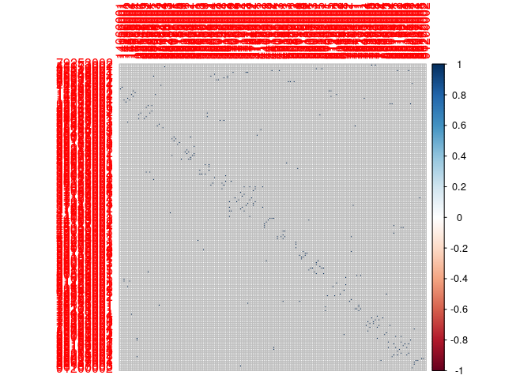

```r
A <- as.data.frame(A)
A <- A %>% dplyr::select(colnames(X_t))
A <-  A %>%  filter(row.names(A) %in% colnames(X_t) )
A <- as.matrix(A)
hatA = matrix(0,p_t,p_t)

#correction
seuil = 0.05/(p_t^2)

hatA[Pvalue_np < seuil] = 1


corrplot(A) # Objectif : entrées non-nulles de la matrice de précision !
```

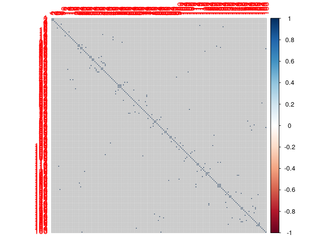

```r
corrplot(hatA) # Estimateur de ces positions non-nulles
```

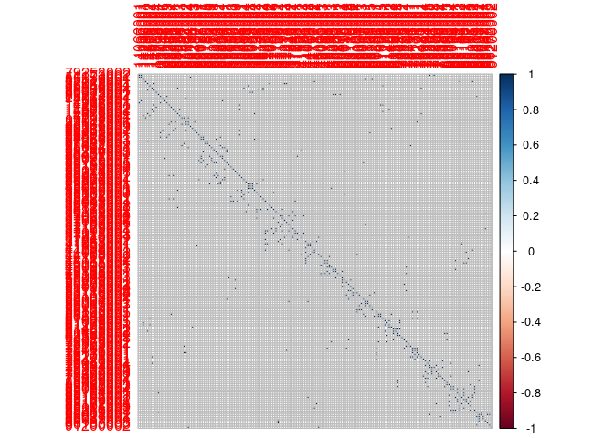

```r
corrplot(abs(hatA-A))
```

```r
W = abs(hatA-A)
sum(W)/(p_t^2-p_t)
```

```
## [1] 0.02197882
```

```r
# Sparsité de A
sum(A)/(p_t^2)
```

```
## [1] 0.009943388
```

```r
# Sparsité de hatA
sum(hatA)/(p_t^2)
```

```
## [1] 0.01262883
```

## Graphical LASSO

On peut montrer que estimer $K$ peut revenir à résoudre le problème d’optimisation pénalisée suivant:

$$min_{K \in S_p} -\frac{n}{2}logdet(K )+\frac{n}{2}<K,\hat{\Sigma_n}>_F+\lambda\sum_{i\neq j}|K_{ij|}$$
NB: Voir le cours de M Bigot page 23-24 pour plus de détails.

### Visualisation du résultat

```r
names(glasso.res)
```

```
##  [1] "method"     "path"       "lambda"     "icov"       "df"
##  [6] "sparsity"   "loglik"     "cov.input"  "cov.output" "scr"
## [11] "data"
```

### Liste des valeurs de lambda

```r
glasso.res$lambda
```

```
##  [1] 0.99896149 0.77345960 0.59886168 0.46367685 0.35900814 0.27796697
##  [7] 0.21521973 0.16663682 0.12902084 0.09989615
```

### Niveau de sparsité associé

```r
glasso.res$sparsity
```

```
##  [1] 0.0000000 0.8086893 0.7657539 0.7052939 0.6356700 0.5670683 0.5000000
##  [8] 0.4350128 0.3815991 0.3320920
```

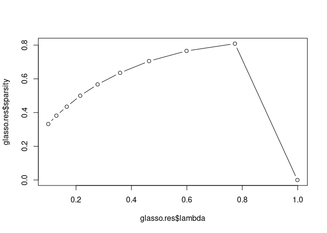

```r
plot(glasso.res$lambda,glasso.res$sparsity,type='b')
```

### Vraisemblance

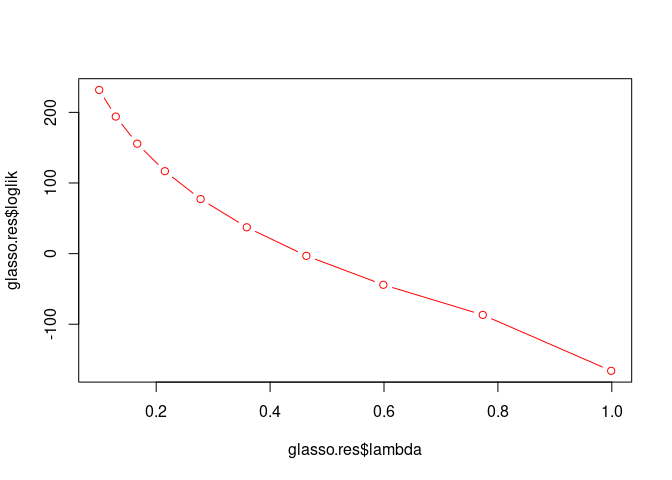

```r
plot(glasso.res$lambda,glasso.res$loglik,type='b',col='red')
```

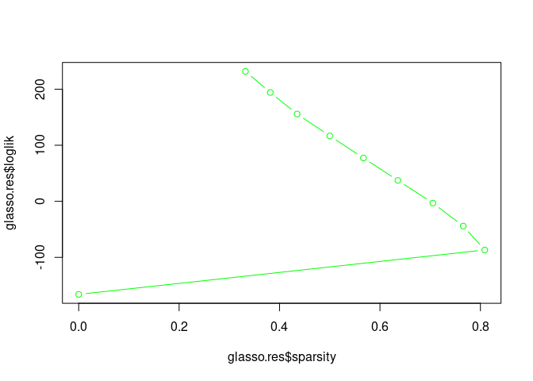

```r
plot(glasso.res$sparsity,glasso.res$loglik,type='b',col='green')
```

### Choix de l’estimateur correspondant à la k-ème valeur de lambda

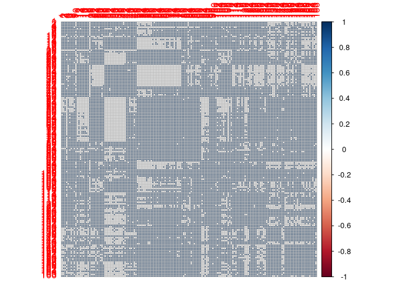

```r
k = 3
p = ncol(X_t)
hatA_LASSO = glasso.res$path[[k]]

corrplot(diag(p)+hatA_LASSO)
```

```r
sum(hatA_LASSO)/(p^2)
```

```
## [1] 0.7611409
```

### Critère STARS

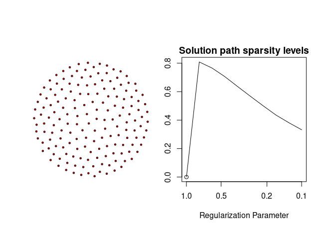

```r
plot(glasso.res.select)
```

```r
names(glasso.res.select)
```

```
##  [1] "method"       "path"         "lambda"       "icov"         "df"
##  [6] "sparsity"     "loglik"       "cov.input"    "cov.output"   "scr"
## [11] "data"         "merge"        "variability"  "opt.index"    "refit"
## [16] "opt.lambda"   "opt.sparsity" "opt.icov"     "criterion"
```

### Choix de lambda

```r
glasso.res.select$opt.index
```

```
## [1] 1
```

```r
glasso.res.select$opt.lambda
```

```
## [1] 0.9989615
```

```r
glasso.res.select$opt.sparsity
```

```
## [1] 0
```

### Visualisation du résultat

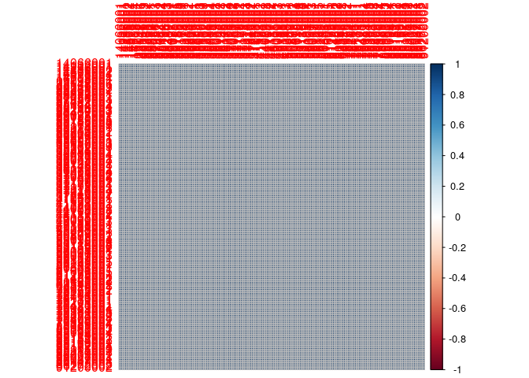

```r
A = K
A[abs(A) > 0] = 1
corrplot(A)
```

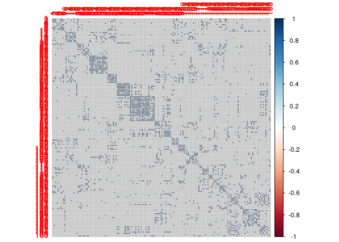

```r
corrplot(hatA_LASSO_CV)
```

```r
### Pourcentage d'erreur
sum(abs(hatA_LASSO_CV-A))/(p^2-p)
```

```
## [1] 0.9006572
```

## Résumé

Ces méthodes d’estimation de lien permettent d’illustrer à l’aide d’un graphe la liaison entre les variables.

Ce projet nous a permis de prendre en main ces outils et d’illustrer dans un cas pratique.

Toutefois, un modèle graphique reste difficile à lire lorsque nous avons un nombre conséquent de nœuds.

Il faut considérer avec beaucoup de précautions nos résultats car nous avons fait une hypothèse de normalité sur la distribution de la variable température, sans vérification au préalable.